# Chapter8

# Plot forecasts from an ARIMA(0,2,1) model with no constant.

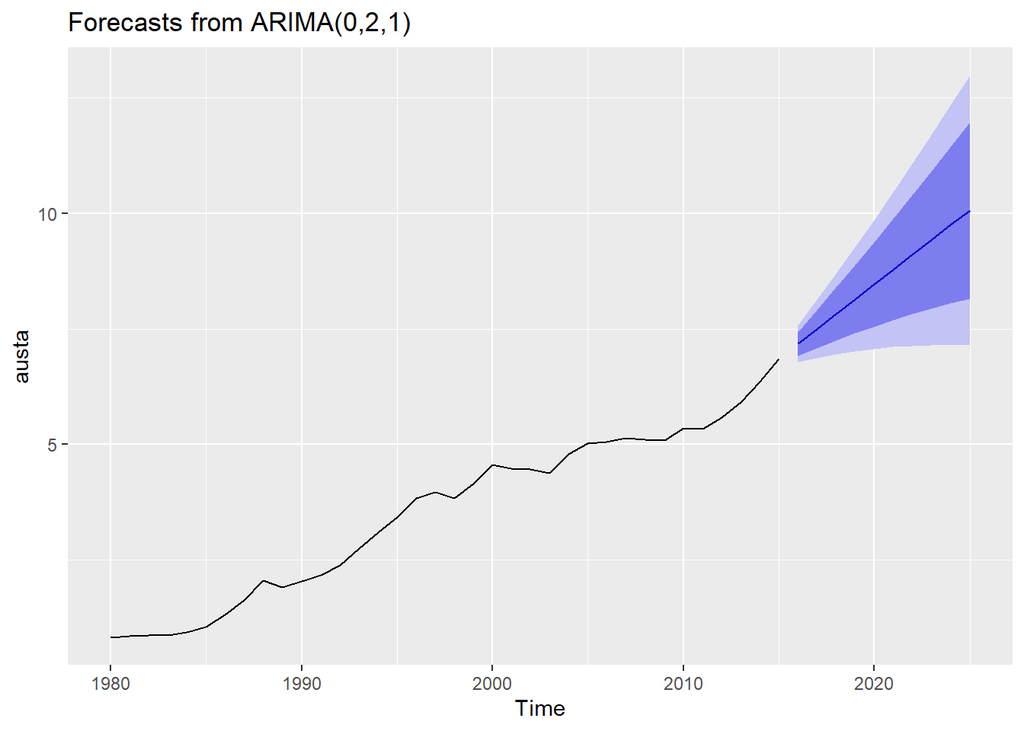

```r
austa.arima021 <- forecast(Arima(austa, order = c(0,2,1)), h = 10)
autoplot(austa.arima021)
```

## Exercitiul 9

# For the usgdp series. If necessary, find a suitable Box-Cox transformation for the data;

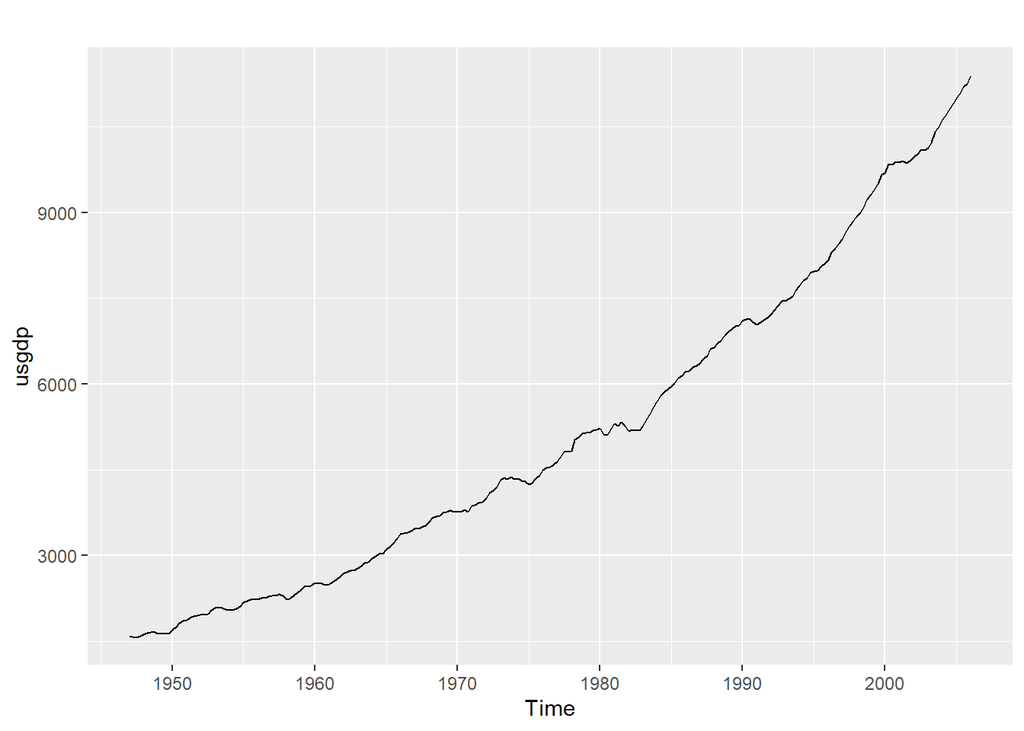

```r
autoplot(usgdp)
```

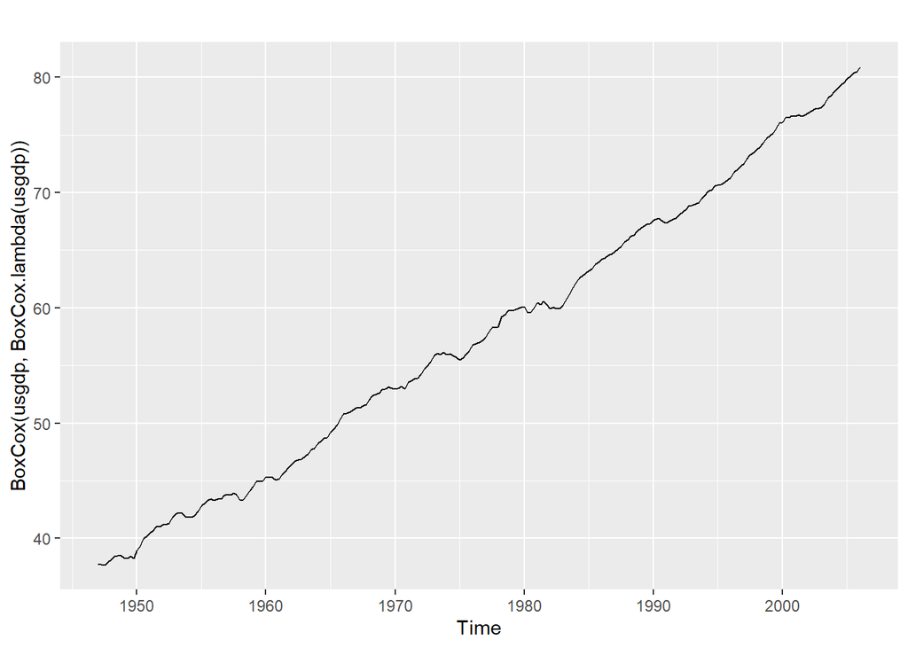

```r
autoplot(BoxCox(usgdp, BoxCox.lambda(usgdp)))
```

```r
us.lambda <- BoxCox.lambda(usgdp)
```

# Fit a suitable ARIMA model to the transformed data using auto.arima();

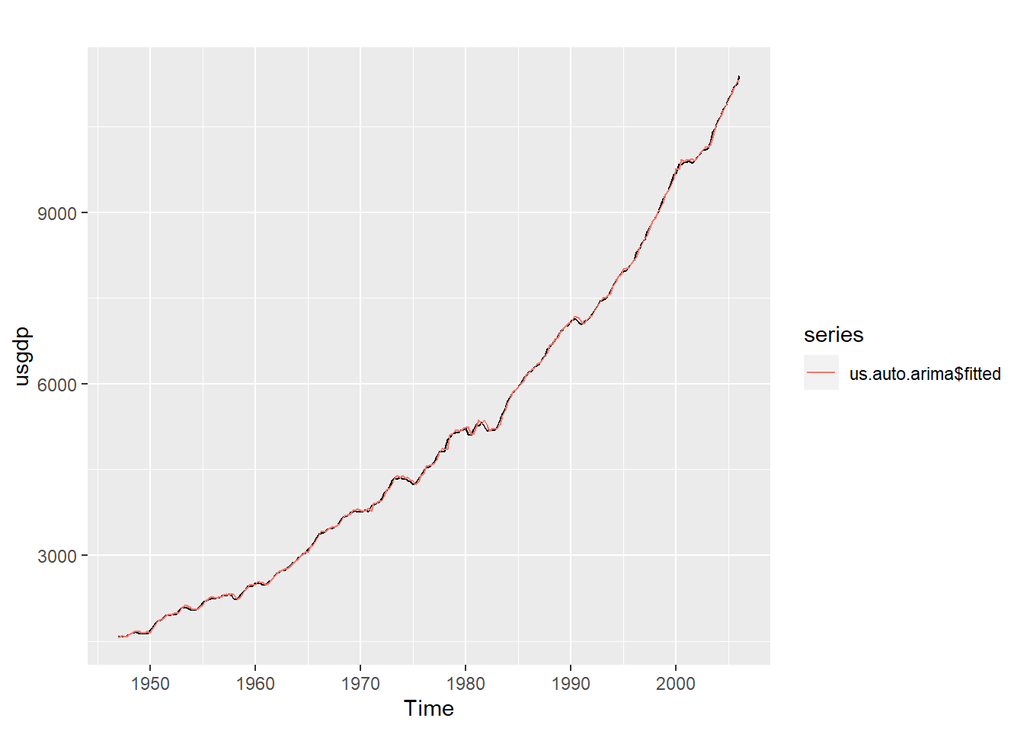

```r
us.auto.arima <- auto.arima(usgdp, lambda = us.lambda)
autoplot(usgdp) + autolayer(us.auto.arima$fitted)
```

Modelul se muleaza bine pe graficul initial usgdp

# Try some other plausible models by experimenting with the orders chosen;

```r
ndiffs(BoxCox(usgdp, us.lambda))
```

```
## [1] 1
```

Avem nevoie de o diferentiere

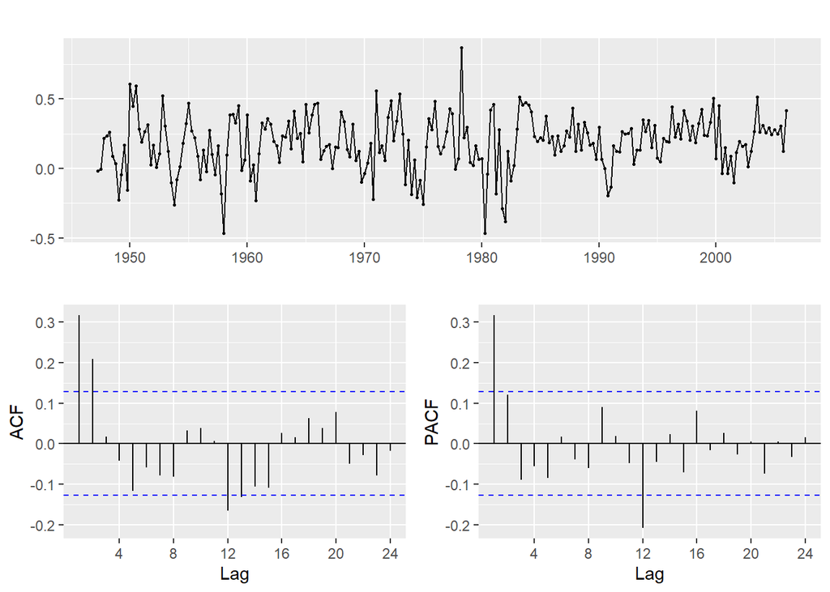

```r
ggtsdisplay(diff(BoxCox(usgdp, us.lambda)))
```

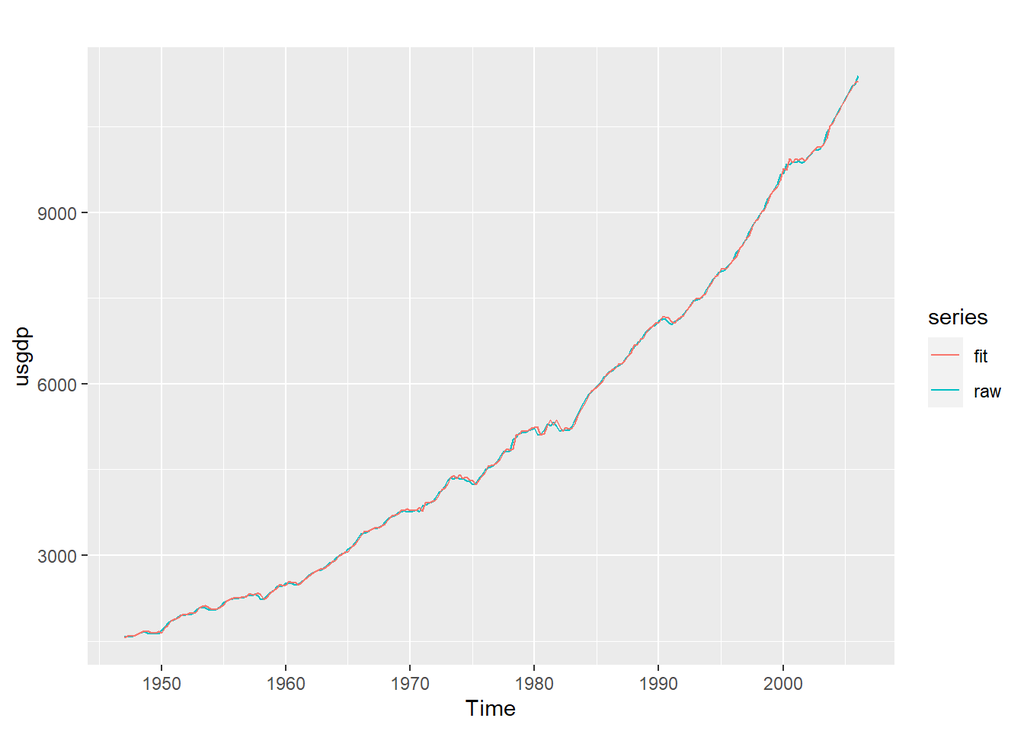

```r
us.arima110drift <- Arima(usgdp, lambda = us.lambda, order = c(1,1,0), include.drift = TRUE)
autoplot(usgdp, "raw") + autolayer(us.arima110drift$fitted, series = "fit")
```

# Choose what you think is the best model and check the residual diagnostics;

```r
accuracy(us.arima110drift)
```

```
##                    ME     RMSE     MAE         MPE      MAPE      MASE
## Training set 1.315796 39.90012 29.5802 -0.01678591 0.6834509 0.1671794
##                     ACF1
## Training set -0.08544569
```

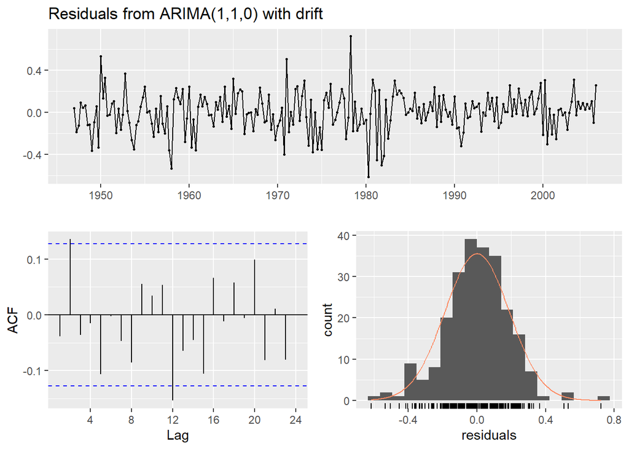

```
##
##  Ljung-Box test
##
## data:  Residuals from ARIMA(1,1,0) with drift
## Q* = 10.274, df = 6, p-value = 0.1136
##
## Model df: 2.   Total lags used: 8
```

```r
checkresiduals(us.arima110drift)
```

# Produce forecasts of your fitted model. Do the forecasts look reasonable?

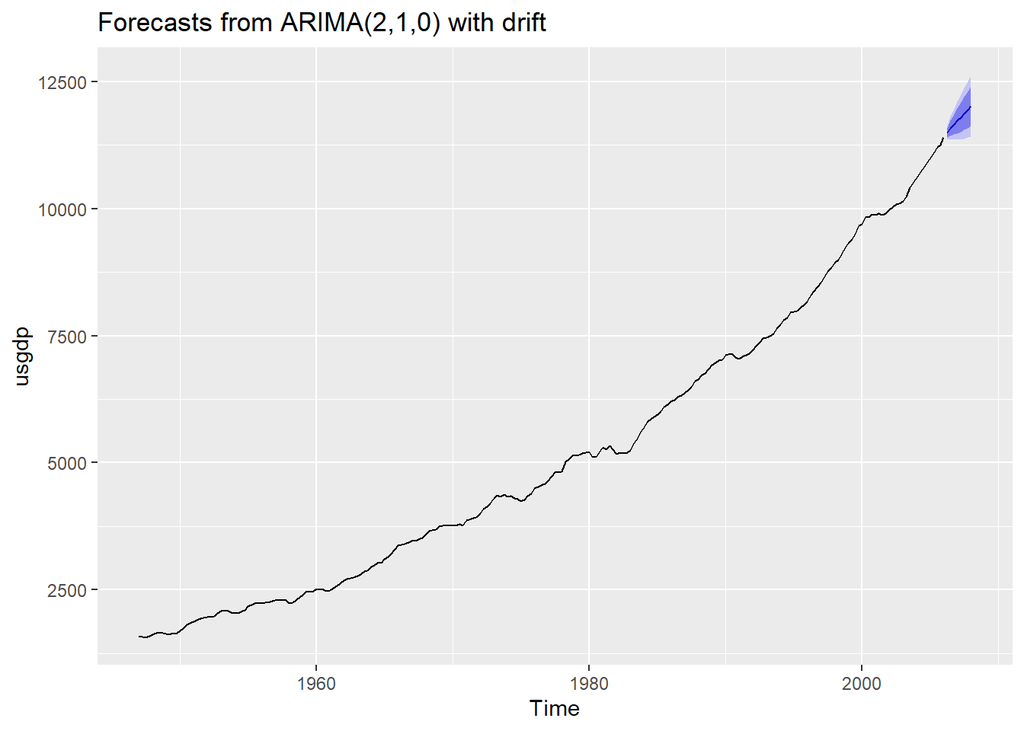

```r
usgdp.autoarima <- forecast(us.auto.arima)
autoplot(usgdp.autoarima)
```

# Compare the results with what you would obtain using ets() (with no transformation).

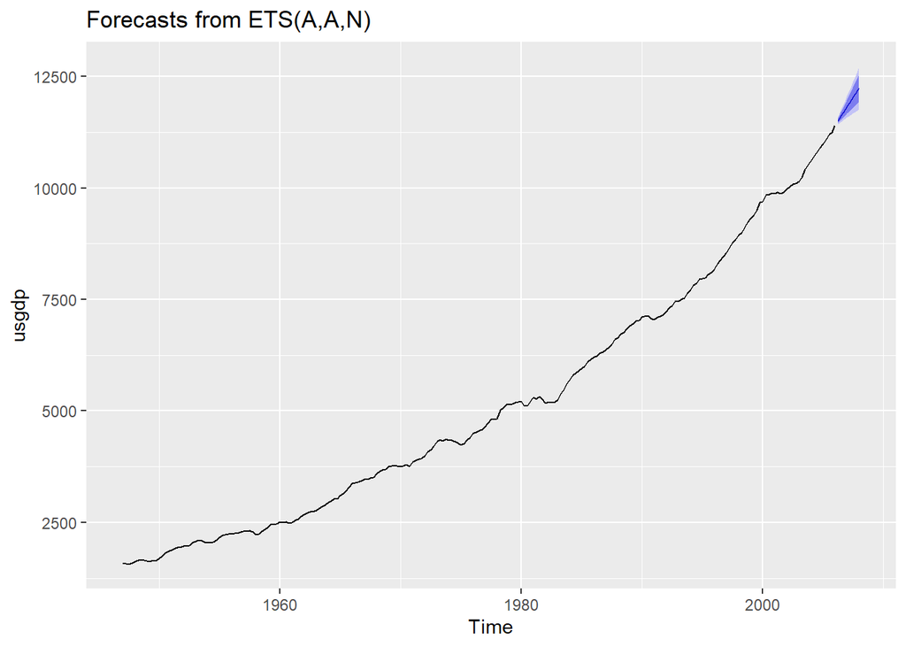

```r
us.ets <- forecast(ets(usgdp))
autoplot(us.ets)
```

## EXERCITIUL 13

# Choose one of the following seasonal time series: hsales, auscafe, qauselec, qcement, qgas.

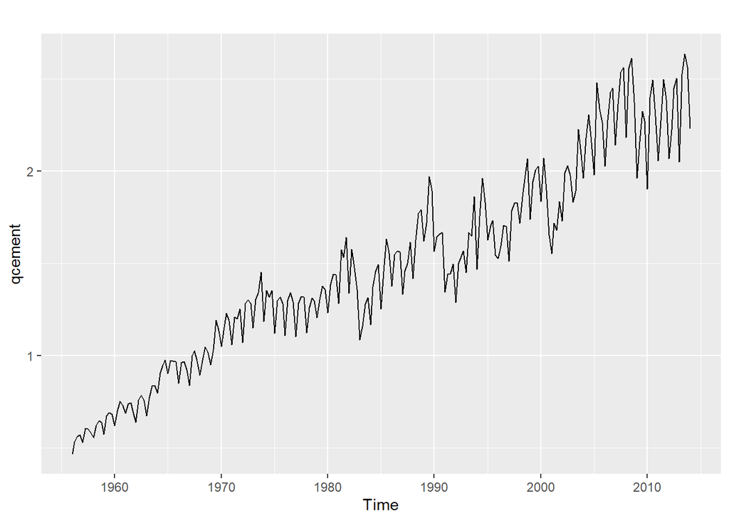

```r
autoplot(qcement)
```

Aplicam o transformare Boxcox pentru a uniformiza variatiile

```r
lambda.qcement <- BoxCox.lambda(qcement)
```

# Are the data stationary? If not, find an appropriate differencing which yields stationary data.

# Datele au sezonalitate si un trend ascedent

```r
ndiffs(qcement)
```

```
## [1] 1
```

Avem nevoie de o diferentiere

```r
kpss.test(diff(qcement, lag = 2))
```

```
##
##  KPSS Test for Level Stationarity
##
## data:  diff(qcement, lag = 2)
## KPSS Level = 0.018306, Truncation lag parameter = 4, p-value = 0.1
```

# Identify a couple of ARIMA models that might be useful in describing the time series. Which of your models is the best according to their AIC values?

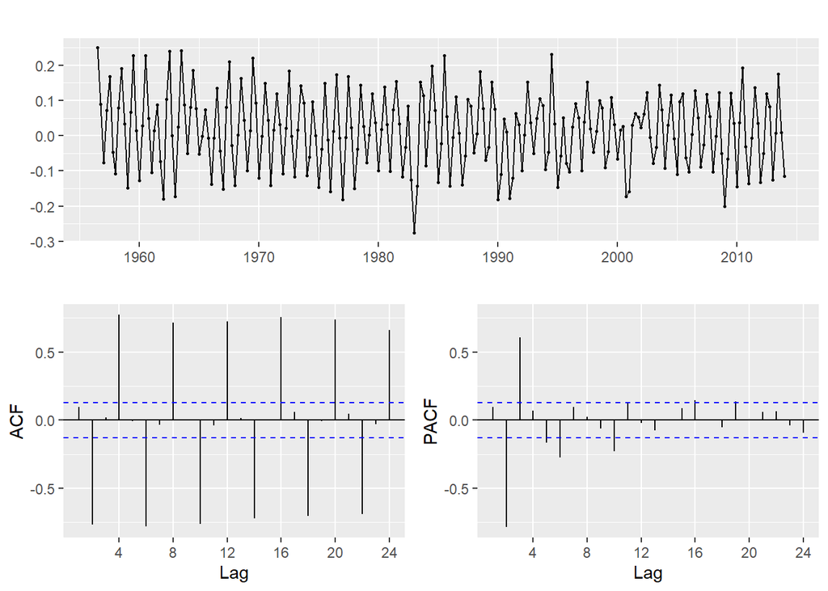

```r
ggtsdisplay(diff(BoxCox(qcement, lambda.qcement), lag = 2))
```

```r
qcement.arima <- Arima(qcement, lambda = lambda.qcement, order = c(0,1,1), seasonal = c(0,1,1))

qcement.arima
```

```
## Series: qcement
## ARIMA(0,1,1)(0,1,1)[4]
## Box Cox transformation: lambda= -0.4319725
##
## Coefficients:
##           ma1     sma1
##       -0.1962  -0.8909
## s.e.   0.0584   0.0353
##
## sigma^2 estimated as 0.001677:  log likelihood=402.84
## AIC=-799.68   AICc=-799.57   BIC=-789.39
```

```r
qcement.arima.lambda <- auto.arima(qcement, lambda = lambda.qcement)

qcement.arima.lambda
```

```
## Series: qcement
## ARIMA(1,1,0)(1,1,2)[4]
## Box Cox transformation: lambda= -0.4319725
##
## Coefficients:
##           ar1     sar1     sma1     sma2
##       -0.2174  -0.5432  -0.2417  -0.5970
## s.e.   0.0660   0.2202   0.1998   0.1719
##
## sigma^2 estimated as 0.001643:  log likelihood=406.17
## AIC=-802.35   AICc=-802.08   BIC=-785.2
```

# Estimate the parameters of your best model and do diagnostic testing on the residuals. Do the residuals resemble white noise? If not, try to find another ARIMA model which fits better.

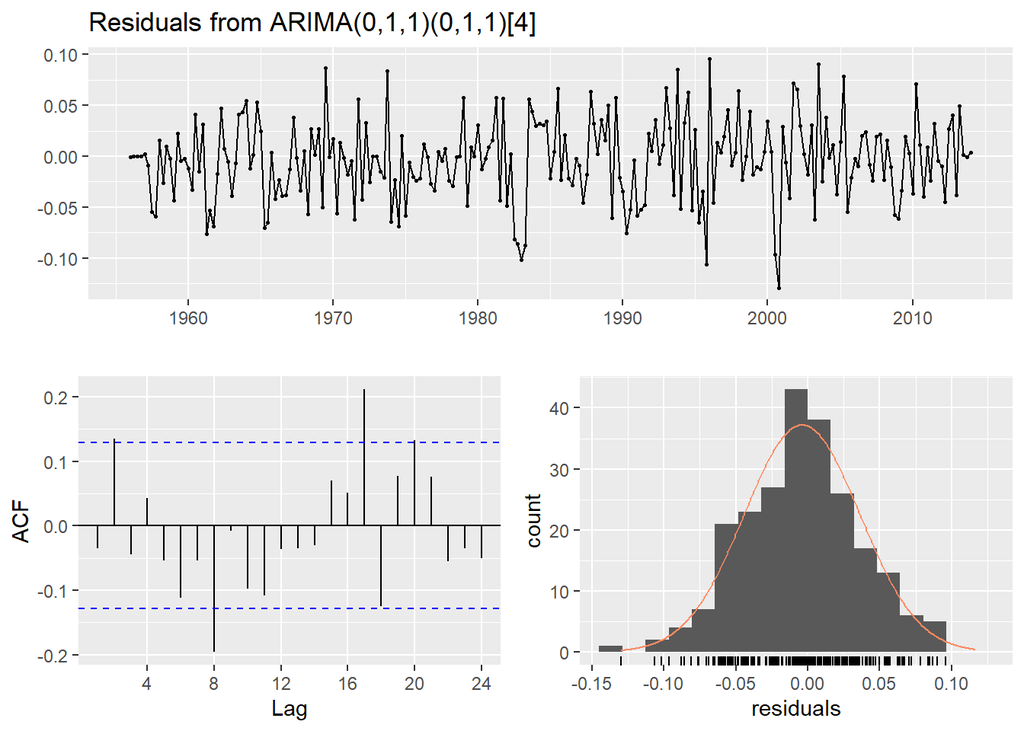

```
##
##  Ljung-Box test
##
## data:  Residuals from ARIMA(0,1,1)(0,1,1)[4]
## Q* = 19.295, df = 6, p-value = 0.003694
##
## Model df: 2.   Total lags used: 8
```

```r
checkresiduals(qcement.arima)
```

# Forecast the next 24 months of data using your preferred model.

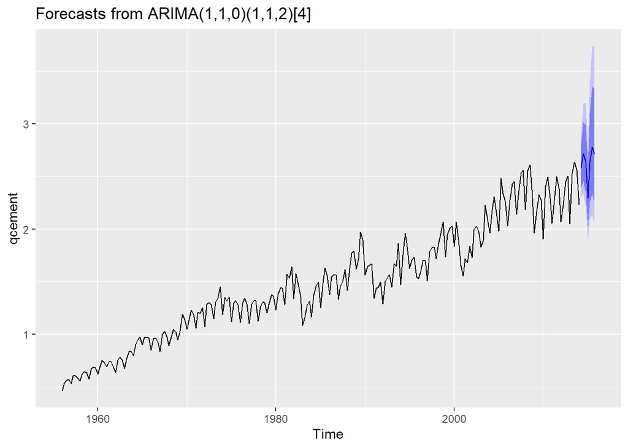

```r
qcement.autoarima <- forecast(qcement.arima.lambda, h = 7)
autoplot(qcement.autoarima)
```